# КонтрольЗаИспользованиемУстройств

Контроль за использованием устройств

### Содержание

- Условия реакции на события
- Действия Агента
  - Блокировка пользовательской сессии и устройства
  - Отслеживание Агентом привязки сессии пользователя к подключенному устройству
  - Конфигурация сообщения

Система позволяет задать настройки использования для привязанных к Агенту устройств. Доступные устройства могут быть найдены в разделе [Контроль](https://guides.indeed-company.ru/pages/viewpage.action?pageId=5447507) политики Indeed Certificate Manager.

### Условия реакции на события

Пользователем Системы могут быть выставлены следующие условия реакции на события:

1. При нарушении условий привязки устройства к агенту. Данное условие будет считаться выполненным, если пользователь подключил к своей рабочей станции чужую смарт-карту, которая не привязана к его Агенту.
2. При нарушении условий привязки устройства и пользователя. Данное условие будет считаться выполненным, если пользователь выполнил вход на рабочую станцию по смарт-карте, привязанной к его Агенту, но затем сменил учетную запись в операционной системе.

Контроль за привязкой устройств к Агенту не осуществляется для пользователей составного каталога и каталога КриптоПро УЦ 2.0.

### Действия Агента

При выполнении условий реакции на указанные пользователем события, доступны следующие действия Агента:

1. Запись события в журнал Indeed CM.
2. Блокировка пользовательской сессии, запись события.
3. Блокировка устройства, запись события.
4. Блокировка пользовательской сессии и устройства, запись события.

#### Блокировка пользовательской сессии и устройства

В случае, если пользователь выбрал действие **Блокировка пользовательской сессии** или **Блокировка пользовательской сессии и устройства**, необходимо указать таймаут до блокировки пользовательской сессии. Максимальное доступное значение - 5 секунд.

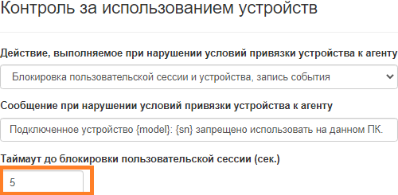

#### Отслеживание Агентом привязки сессии пользователя к подключенному устройству

При необходимости отслеживания Агентом привязки сессии пользователя к подключенному устройству необходимо включить опцию **Включить проверку привязки устройства к пользователю**.

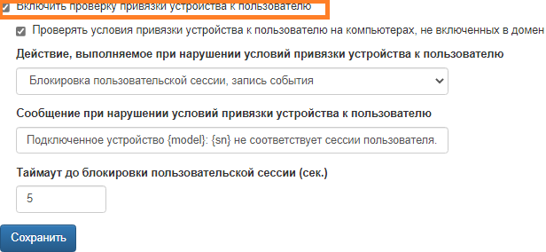

Если предполагается использование Агентов и устройств на рабочих станциях, не входящих в домен организации, необходимо активировать опцию **Проверять условия привязки устройства к пользователю на компьютерах, не включенных в домен**.

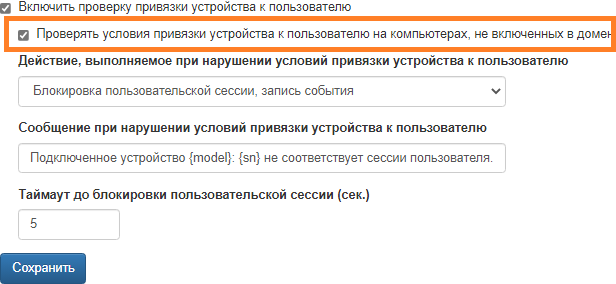

#### Конфигурация сообщения

В случае, когда указанные пользователем условия выполнены не были, возможно настроить сообщение, которое Система будет отображать на графическом интерфейсе (или в логах). Для этого необходимо в поле **Сообщение при нарушении условий привязки устройства к пользователю** указать один из доступных атрибутов:

1. {sn} – вывод серийного номера устройства
2. {atr} – вывод значения ATR устройства
3. {model} – вывод модели устройства
4. {label} – вывод метки устройства

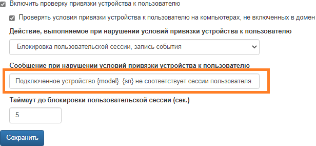